# Bolt-HA-Hitendra

```python
import warnings
warnings.simplefilter("ignore", UserWarning)
```

```python
#Visualization libraries
import matplotlib.pyplot as plt
import seaborn as sns

import numpy as np # linear algebra
import pandas as pd # data processing
import json #filt I/O operations

#utility imports
from datetime import datetime, timedelta
from geopy import distance
import libgeohash as libgh
import itertools

#Time-series modelling libraries
import statsmodels.api as sm
from statsmodels.tsa.seasonal import seasonal_decompose

#Clustering
from sklearn.cluster import MiniBatchKMeans, KMeans

#Performance metrics
from sklearn.metrics import mean_absolute_error
from sklearn.metrics import mean_squared_error
from sklearn.metrics import r2_score

pd.options.mode.chained_assignment = None  # default='warn'
```

```python
from google.colab import drive
drive.mount('/content/drive')
```

```python
data_initial = pd.read_csv("/content/drive/My Drive/Home assignment/robotex5.csv")
data_initial.head()
```

|  | start_time | start_lat | start_lng | end_lat | end_lng | ride_value |
| --- | --- | --- | --- | --- | --- | --- |
| 0 | 2022-03-06 15:02:39.329452000 | 59.407910 | 24.689836 | 59.513027 | 24.831630 | 3.51825 |
| 1 | 2022-03-10 11:15:55.177526000 | 59.441650 | 24.762712 | 59.426450 | 24.783076 | 0.50750 |
| 2 | 2022-03-06 14:23:33.893257000 | 59.435404 | 24.749795 | 59.431901 | 24.761588 | 0.19025 |
| 3 | 2022-03-03 09:11:59.104192000 | 59.406920 | 24.659006 | 59.381093 | 24.641652 | 0.75600 |
| 4 | 2022-03-06 00:13:01.290346000 | 59.434940 | 24.753641 | 59.489203 | 24.876170 | 2.27100 |

```python
#data_initial = pd.read_csv("/content/drive/My Drive/Home assignment/ride_data_with_car_distance_and_eagle_distance.csv")
#data_initial.head()
```

```python
data_with_distance = data_initial.copy()
data_with_distance['start_time'] = pd.to_datetime(data_with_distance['start_time'], format='%Y-%m-%d %H:%M:%S')
data_with_distance['start_time'] = data_with_distance['start_time'].round('S')
#del data_with_distance["Unnamed: 0"]
data_with_distance
```

|  | start_time | start_lat | start_lng | end_lat | end_lng | ride_value |
| --- | --- | --- | --- | --- | --- | --- |
| 0 | 2022-03-06 15:02:39 | 59.407910 | 24.689836 | 59.513027 | 24.831630 | 3.518250 |
| 1 | 2022-03-10 11:15:55 | 59.441650 | 24.762712 | 59.426450 | 24.783076 | 0.507500 |
| 2 | 2022-03-06 14:23:34 | 59.435404 | 24.749795 | 59.431901 | 24.761588 | 0.190250 |
| 3 | 2022-03-03 09:11:59 | 59.406920 | 24.659006 | 59.381093 | 24.641652 | 0.756000 |
| 4 | 2022-03-06 00:13:01 | 59.434940 | 24.753641 | 59.489203 | 24.876170 | 2.271000 |
| ... | ... | ... | ... | ... | ... | ... |
| 627205 | 2022-03-16 06:19:39 | 59.489132 | 24.870559 | 59.426810 | 24.672892 | 3.232051 |
| 627206 | 2022-03-12 08:33:16 | 59.428616 | 24.771929 | 59.439053 | 24.873362 | 1.436750 |
| 627207 | 2022-03-16 06:20:33 | 59.387015 | 24.705160 | 59.422822 | 24.697156 | 0.993888 |
| 627208 | 2022-03-10 01:08:18 | 59.441934 | 24.754971 | 59.437759 | 24.775483 | 0.307250 |
| 627209 | 2022-03-20 21:05:50 | 59.439201 | 24.761567 | 59.426927 | 24.552130 | 2.925750 |

627210 rows × 6 columns

```python
data_with_distance.describe([0.90, 0.95, 0.975, 0.998, 0.9985, 0.9990,0.9995, 0.9999])
```

|  | start_lat | start_lng | end_lat | end_lng | ride_value |
| --- | --- | --- | --- | --- | --- |
| count | 627210.000000 | 627210.000000 | 627210.000000 | 627210.000000 | 627210.000000 |
| mean | 59.428682 | 24.743468 | 59.397797 | 24.724847 | 2.261384 |
| std | 0.021764 | 0.056872 | 1.392755 | 1.650709 | 44.889892 |
| min | 59.321557 | 24.505199 | -37.819979 | -122.453962 | 0.107628 |
| 50% | 59.432069 | 24.744674 | 59.430697 | 24.744335 | 1.059000 |
| 90% | 59.446333 | 24.820324 | 59.447971 | 24.831502 | 2.481750 |
| 95% | 59.453010 | 24.848725 | 59.456417 | 24.863320 | 3.038500 |
| 97.5% | 59.476288 | 24.875041 | 59.487180 | 24.884170 | 3.555500 |
| 99.8% | 59.519480 | 24.924701 | 59.533447 | 25.020125 | 6.479623 |
| 99.85% | 59.521869 | 24.930944 | 59.543885 | 25.023458 | 7.774000 |
| 99.9% | 59.525361 | 24.941572 | 59.546330 | 25.071670 | 23.204750 |
| 99.95% | 59.537407 | 24.953659 | 59.550679 | 25.190952 | 674.806158 |
| 99.99% | 59.552238 | 24.961239 | 59.565604 | 36.474312 | 2858.234927 |
| max | 59.566998 | 24.973743 | 61.552744 | 144.966110 | 3172.701000 |

few observations:

- average **end_lat** value is **59.397797** and average **end_lng** is **24.724847**
  - mininum value for end_lat is -37.819979 which is very far as standrad deviation is ~1.39 that shows presence of outliers
  - minimum value for end_lng is around -122 and maximum value is around 144 with standard deviation of 1.65 shows an presence of outliers
- ride_value has mean 2.26 and std dev 44 now if it follows normal distribution then 95% of total observations should be in [mean-2*std, mean+2*std] but 95%tile is at 3.03 which means it is skewed and not normally distributed.
- as 99.8%tile data is having ride_value <= 6.47 we can remove data above that and consider them as an outlier

```python
data_without_outliers = data_with_distance[(data_with_distance.ride_value<6.50)]
data_without_outliers.head()
```

|  | start_time | start_lat | start_lng | end_lat | end_lng | ride_value |
| --- | --- | --- | --- | --- | --- | --- |
| 0 | 2022-03-06 15:02:39 | 59.407910 | 24.689836 | 59.513027 | 24.831630 | 3.51825 |
| 1 | 2022-03-10 11:15:55 | 59.441650 | 24.762712 | 59.426450 | 24.783076 | 0.50750 |
| 2 | 2022-03-06 14:23:34 | 59.435404 | 24.749795 | 59.431901 | 24.761588 | 0.19025 |
| 3 | 2022-03-03 09:11:59 | 59.406920 | 24.659006 | 59.381093 | 24.641652 | 0.75600 |
| 4 | 2022-03-06 00:13:01 | 59.434940 | 24.753641 | 59.489203 | 24.876170 | 2.27100 |

```python
data_without_outliers['distance_eagle'] = data_without_outliers.apply(lambda x: distance.distance((x.start_lat, x.start_lng), (x.end_lat, x.end_lng)).km, axis=1)
```

```python
corr = data_without_outliers[["ride_value","distance_eagle"]].corr()
print(corr['ride_value']['distance_eagle'])
```

```
0.9999026891398322
```

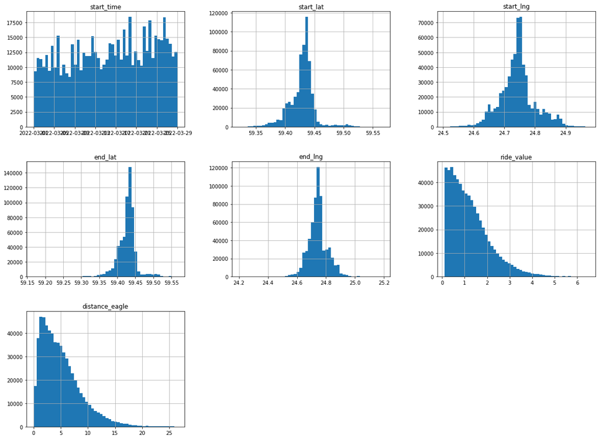

```python
data_without_outliers.hist(bins=50, figsize=(20,15))
plt.show()
```

```python
data_without_outliers['hour_of_day'] = data_without_outliers.apply(lambda x: x.start_time.hour , axis=1)
data_without_outliers['day_of_week'] = data_without_outliers.apply(lambda x: x.start_time.strftime('%A') , axis=1)
data_without_outliers['day_of_month'] = data_without_outliers.apply(lambda x: x.start_time.day , axis=1)
data_without_outliers['working_day'] = data_without_outliers.apply(lambda x: 0 if x.start_time.strftime('%A') in ["Sunday", "Saturday"] else 1, axis=1)
```

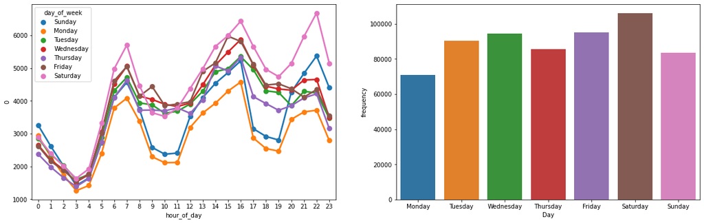

```python
fig, ax = plt.subplots(1,2, figsize=(20, 6))

hueOrder = ["Sunday","Monday","Tuesday","Wednesday","Thursday","Friday","Saturday"]
hourAggregated = pd.DataFrame(data_without_outliers.groupby(["hour_of_day","day_of_week"],sort=True).size()).reset_index()
sns.pointplot(x=hourAggregated["hour_of_day"], y=hourAggregated[0],hue=hourAggregated["day_of_week"],hue_order=hueOrder, data=hourAggregated, ax=ax[0])

head = data_without_outliers.groupby(["day_of_week"]).size()
head = head.reindex(index = ["Monday", "Tuesday", "Wednesday", "Thursday", "Friday", "Saturday", "Sunday"])
category_df = head.reset_index()
category_df.columns = ['Day', 'frequency']
sns.barplot(x = 'Day', y = 'frequency', data = category_df, ax=ax[1] )
```

- Saturday is the Highest demand day
- 7AM, 4PM and 10PM is the highest demand hours

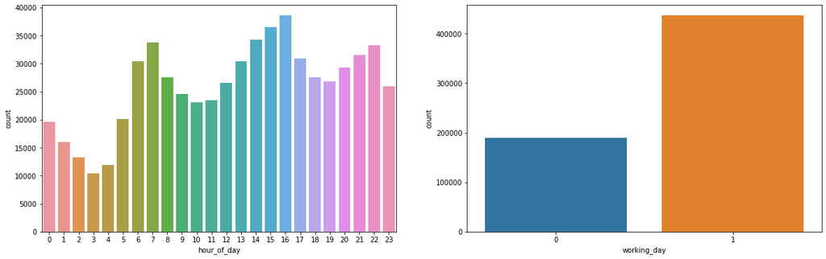

```python
fig, ax =plt.subplots(1,2, figsize=(20, 6))
sns.countplot(x="hour_of_day", data=data_without_outliers, ax=ax[0])
sns.countplot(x="working_day", data=data_without_outliers, ax=ax[1])
```

- We can see that around 7 AM, 4 PM usually a peak hours has a high number of demands

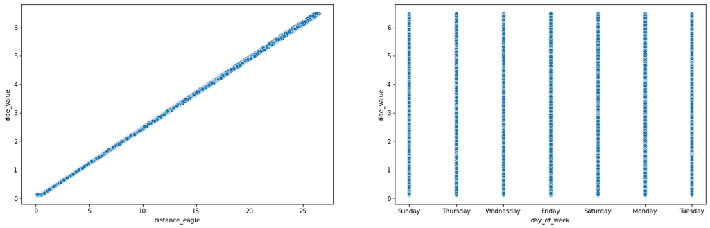

```python
fig, ax = plt.subplots(1,2, figsize=(20, 6))
sns.scatterplot(x="distance_eagle", y="ride_value", data=data_without_outliers, ax=ax[0])
sns.scatterplot(x="day_of_week", y="ride_value", data=data_without_outliers, ax=ax[1])
```

As we removed the outliers, we can observe that as distance increase the ride value will also increase.

# Modelling

Definitely a **time series problem**. But we need also to suggest a driver to **a nearest area which has high demand(high ride value).**

That requires us to do some clustering and on each cluster we can forecast

- **clustering on whole data** (KMeans or variation of KMeans)
- **Forecast** using
  - **ARIMA** Family
  - Classical **ML Regression algo** (XGBoost, SVM regression, Linear Regression etc., but first need to formalize it as supervise learning problem)
  - **Deep Learning** (LSTM)

## Clustering

```python
start_geohash = data_without_outliers.apply(lambda x: libgh.encode(x.start_lat, x.start_lng, precision=5), axis=1)
number_of_clusters = len(start_geohash.unique())
```

```python
# clustering
coord = data_without_outliers[["start_lat", "start_lng"]].values
regions = MiniBatchKMeans(n_clusters = number_of_clusters, batch_size = 10000, random_state=1).fit(coord)
```

```python
centroids = regions.cluster_centers_
```

```python
cluster_column = regions.predict(data_without_outliers[["start_lat", "start_lng"]])
data_without_outliers["pickup_cluster"] = cluster_column
data_without_outliers.head()
```

|  | start_time | start_lat | start_lng | end_lat | end_lng | ride_value | distance_eagle | hour_of_day | day_of_week | day_of_month | working_day | pickup_cluster |
| --- | --- | --- | --- | --- | --- | --- | --- | --- | --- | --- | --- | --- |
| 0 | 2022-03-06 15:02:39 | 59.407910 | 24.689836 | 59.513027 | 24.831630 | 3.51825 | 14.205080 | 15 | Sunday | 6 | 0 | 22 |
| 1 | 2022-03-10 11:15:55 | 59.441650 | 24.762712 | 59.426450 | 24.783076 | 0.50750 | 2.050095 | 11 | Thursday | 10 | 1 | 5 |
| 2 | 2022-03-06 14:23:34 | 59.435404 | 24.749795 | 59.431901 | 24.761588 | 0.19025 | 0.774715 | 14 | Sunday | 6 | 0 | 32 |
| 3 | 2022-03-03 09:11:59 | 59.406920 | 24.659006 | 59.381093 | 24.641652 | 0.75600 | 3.041401 | 9 | Thursday | 3 | 1 | 4 |
| 4 | 2022-03-06 00:13:01 | 59.434940 | 24.753641 | 59.489203 | 24.876170 | 2.27100 | 9.209442 | 0 | Sunday | 6 | 0 | 32 |

```python
data_without_outliers.rename(columns={'start_time':'time','ride_value':'demand',},inplace=True)
grouped_order_data = data_without_outliers[["pickup_cluster", "time", "demand"]].groupby(by = ["pickup_cluster", "time"]).count()
grouped_order_data.head()
```

| pickup_cluster | time | demand |
| --- | --- | --- |
| 0 | 2022-03-01 00:00:08 | 1 |
|  | 2022-03-01 00:00:36 | 1 |
|  | 2022-03-01 00:01:58 | 1 |
|  | 2022-03-01 00:03:59 | 1 |
|  | 2022-03-01 00:06:28 | 1 |

```python
def create_features(df):
  #Resampling Data in region j into one hour step
  df = df.resample('1h').sum()
  #Feature Engineering
  df['Date time'] = df.index
  df['Date time'] = pd.to_datetime(df['Date time'].dt.strftime('%Y-%m-%d %H'))
  df['hour'] = df['Date time'].dt.hour
  df['day'] = df['Date time'].dt.day
  df['dayofweek'] = df['Date time'].dt.dayofweek
  df['workingday'] = df.apply(lambda x: 1 if x.dayofweek < 5 else 0, axis=1)
  df['demand'] = df['demand'].fillna(0)
  return df
```

#### Take one cluster and apply forecasting techniques

```python
def sarimax_gridsearch(ts, pdq, pdqs, maxiter=5, freq='H'):
    # Run a grid search with pdq and seasonal pdq parameters and get the best BIC value
    ans = []
    for comb in pdq:
        for combs in pdqs:
            try:
                mod = sm.tsa.statespace.SARIMAX(ts, # this is your time series you will input
                                                order=comb,
                                                seasonal_order=combs,
                                                enforce_stationarity=False,
                                                enforce_invertibility=False,
                                                freq=freq)

                output = mod.fit(maxiter=maxiter)
                ans.append([comb, combs, output.bic])
                print('SARIMAX {} x {}24 : BIC Calculated ={}'.format(comb, combs, output.bic))
            except:
                continue

    # Find the parameters with minimal BIC value

    # Convert into dataframe
    ans_df = pd.DataFrame(ans, columns=['pdq', 'pdqs', 'bic'])

    # Sort and return top 5 combinations
    ans_df = ans_df.sort_values(by=['bic'],ascending=True)[0:5]

    return ans_df.iloc[0]['pdq'],ans_df.iloc[0]["pdqs"]
```

```python
cluster = grouped_order_data.loc[0]
cluster = create_features(cluster)
cluster = cluster[['hour','day','dayofweek','workingday', 'demand']]
print(cluster.head())
```

```
                     hour  day  dayofweek  workingday  demand
time
2022-03-01 00:00:00     0    1          1           1      28
2022-03-01 01:00:00     1    1          1           1      32
2022-03-01 02:00:00     2    1          1           1      23
2022-03-01 03:00:00     3    1          1           1       8
2022-03-01 04:00:00     4    1          1           1      13
```

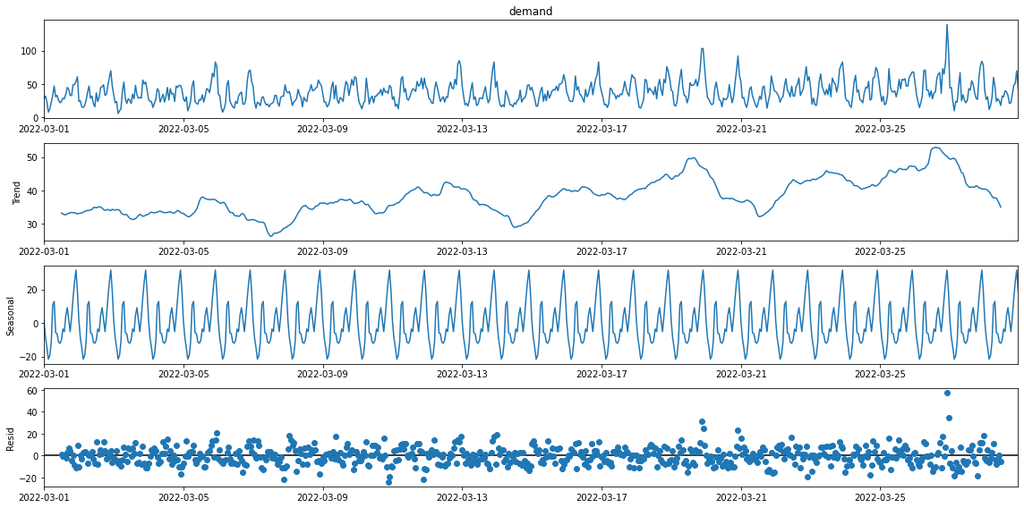

```python
plt.rcParams["figure.figsize"] = (16,8)
result = seasonal_decompose(cluster.demand, model='additive')
result.plot()
plt.show()
```

From above chart we can conclude that seasonality effect is for 24 hour.

```python
values = cluster["demand"]
parts = int(len(values)/3)
rts = int(len(values)/3)

part_1, part_2, part_3 = values[0:parts], values[parts:(parts*2)], values[(parts*2):(parts*3)]
mean_1, mean_2, mean_3 = part_1.mean(), part_2.mean(), part_3.mean()
var_1, var_2, var_3 = part_1.var(), part_2.var(), part_3.var()

print('mean1=%f, mean2=%f, mean2=%f' % (mean_1, mean_2, mean_3))
print('variance1=%f, variance2=%f, variance2=%f' % (var_1, var_2, var_3))
```

```
mean1=33.441964, mean2=38.089286, mean2=42.584821
variance1=197.467469, variance2=211.462844, variance2=381.382908
```

```python
from statsmodels.tsa.stattools import adfuller
values = cluster["demand"]
res = adfuller(values)
print('Augmneted Dickey_fuller Statistic: %f' % res[0])
print('p-value: %f' % res[1])
print('critical values at different levels:')
for k, v in res[4].items():
    print('\t%s: %.3f' % (k, v))
```

```
Augmneted Dickey_fuller Statistic: -4.447974
p-value: 0.000244
critical values at different levels:
	1%: -3.440
	5%: -2.866
	10%: -2.569
```

Data is stationary as we have p-value < 0.05 and AD Fuller stat less than the critical value.

```python
split_date = pd.Timestamp('2022-03-21')
train = cluster.loc[:split_date]
test =  cluster.loc[split_date:]
```

```python
# Define the p, d and q parameters to take any value between 0 and 2 (exclusive)
p = d = q = range(0, 2)

# Generate all different combinations of p, q and q triplets
pdq = list(itertools.product(p, d, q))

pdqs = [(x[0], x[1], x[2], 24) for x in list(itertools.product(p, d, q))]

ans_params = sarimax_gridsearch(train["demand"], pdq, pdqs, freq='H')

order = ans_params[0]
seasonal_order = ans_params[1]
train_data = pd.DataFrame(train['demand'])
train_exog = train.loc[:,['hour', 'day', 'dayofweek', 'workingday']]
test_data = pd.DataFrame(test['demand'])
test_exog = test.loc[:,['hour', 'day', 'dayofweek', 'workingday']]
mod = sm.tsa.statespace.SARIMAX(train_data,exog=train_exog,order=order,seasonal_order=seasonal_order)
results = mod.fit()

preds = results.get_prediction(start=test_data.index[0],end=test_data.index[-1],exog=test_exog.iloc[:-1,:],dynamic=False)
test_forecast = preds.predicted_mean.round()
test_forecast[test_forecast<0] = 0
print('Test Mean Absolute Error:      ', mean_absolute_error(test_data, test_forecast))
print('Test Root Mean Squared Error:  ', np.sqrt(mean_squared_error(test_data, test_forecast)))

result_df = pd.DataFrame(test.demand)
result_df['predicted_value'] = test_forecast
```

[output not shown]

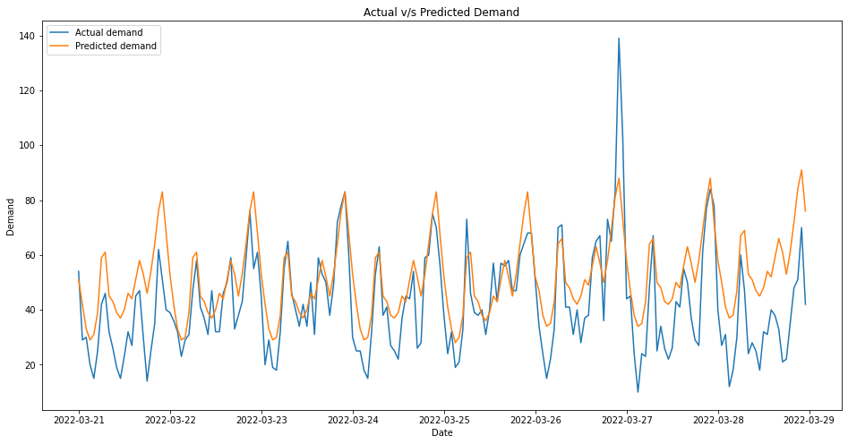

```python
plt.rcParams["figure.figsize"] = (16,8)

# actual demand
plt.plot(result_df.index, result_df['demand'], label="Actual demand")

# predicted demand
plt.plot(result_df.index, result_df['predicted_value'], label="Predicted demand")

plt.xlabel("Date")
plt.ylabel("Demand")
plt.title('Actual v/s Predicted Demand')
plt.legend(loc="upper left")
plt.show()
```

```python
for i in range(number_of_clusters):
  cluster = grouped_order_data.loc[i]
  cluster = create_features(cluster)
  cluster = cluster[['hour','day','dayofweek','workingday', 'demand']]
  print(cluster)

  split_date = pd.Timestamp('2022-03-21')
  train = cluster.loc[:split_date]
  test =  cluster.loc[split_date:]

  ans_params = sarimax_gridsearch(train["demand"], pdq, pdqs, freq='H')
  order = ans_params[0]
  seasonal_order = ans_params[1]

  train_data = pd.DataFrame(train['demand'])
  train_exog = train.loc[:,['hour', 'day', 'dayofweek', 'workingday']]
  test_data = pd.DataFrame(test['demand'])
  test_exog = test.loc[:,['hour', 'day', 'dayofweek', 'workingday']]

  mod = sm.tsa.statespace.SARIMAX(train_data,exog=train_exog,order=order,seasonal_order=seasonal_order)
  results = mod.fit()

  preds = results.get_prediction(start=test_data.index[0],end=test_data.index[-1],exog=test_exog.iloc[:-1,:],dynamic=False)
  test_forecast = preds.predicted_mean.round()
  test_forecast[test_forecast<0] = 0

  print('Test Mean Absolute Error:      ', mean_absolute_error(test_data, test_forecast))
  print('Test Root Mean Squared Error:  ', np.sqrt(mean_squared_error(test_data, test_forecast)))

  results_df = pd.DataFrame(test.demand)
  results_df['predicted_value'] = test_forecast

  results_df.append(results_df)
  results_df.to_csv('/content/drive/My Drive/HA-Bolt/Forecast/cluster_{}_predictions.csv'.format(str(i).zfill(2)))

  performance = {"cluster_number": i, "Test MAE": mean_absolute_error(test_data, test_forecast),
                 "Test RMSE": np.sqrt(mean_squared_error(test_data, test_forecast)),
                 "Test R2": r2_score(test_data , test_forecast)}

  cluster_perf_fn = '/content/drive/My Drive/HA-Bolt/Cluster performance/'+str(i).zfill(2)+'_cluster_performance.json'
  with open(cluster_perf_fn, 'w') as fp:
    json.dump(performance, fp)
```

[output not shown]

### How to convey findings to Drivers?

In Real-time we will get driver's current location or current trip's end location.

- We will provide this current location and current time to the model.
  - We will find neighbor clusters to driver's current trip's end location
  - We will access neighbor clusters forecast for the next hour
  - Make a decision to driver, whether to stay in same cluster or to move to near cluster if demand is high

```python
def from_forecast_retrieve_demand(current_time, cluster):
  date = pd.to_datetime(current_time, format='%Y-%m-%d %H:%M:%S')
  next_timestamp = date.floor('H')+pd.Timedelta('1h')
  d = pd.read_csv('/content/drive/My Drive/HA-Bolt/Forecast/cluster_{}_predictions.csv'.format(str(cluster).zfill(2)))
  return d[d["time"]==str(next_timestamp)]["predicted_value"].values[0]

def get_next_cluster(cab_current_location, current_time):
  global regions, centroids

  df = pd.DataFrame()

  df['end_lat'] = [x[0] for x in centroids]
  df['end_lng'] = [x[1] for x in centroids]

  df['start_lat'] = cab_current_location["lat"]
  df['start_lng'] = cab_current_location["lng"]

  df['next_cluster'] = regions.predict(df[["end_lat", "end_lng"]])
  df['current_cluster'] = regions.predict(df[["start_lat", "start_lng"]])

  df['distance_eagle'] = df.apply(lambda x: distance.distance((x.start_lat, x.start_lng), (x.end_lat, x.end_lng)).km, axis=1)
  df.sort_values('distance_eagle', inplace=True)

  tmp = df.head(5).apply(lambda x: from_forecast_retrieve_demand(current_time, int(x["next_cluster"])), axis=1)
  next_cluster = tmp.idxmax()
  return next_cluster
```

```python
index = 75676
cab_lat = data_without_outliers.iloc[index]["start_lat"]
cab_lng = data_without_outliers.iloc[index]["start_lng"]

cab_current_location = {"lat": cab_lat,"lng":cab_lng}
current_time = "2022-03-22 10:53:28"
```

```python
recommended_cluster = get_next_cluster(cab_current_location, current_time)
current_cluster = regions.predict([[cab_lat, cab_lng]])[0]

if recommended_cluster == current_cluster:
  print("Stay in same cluster")
else:
  print("Please move near to cluster number: ",recommended_cluster)
```

```
Please move near to cluster number:  5
```

Please refer [HA-Bolt Forecast](https://drive.google.com/drive/folders/1v1B8dGu_8kZ9xGN1JI8fvIDyUvSnXfdS?usp=share_link) to access performance and forecast for each cluster.

## **Future Scope**

**Dataset**

- I would consider weather data, road data with U-turn, over-bridge, current traffic,under pass information
- OSRM open source API for calculating distance between source and destination by road
- Any planned public event or celebrations data so that people will gather and demand will be high at specific time and location

**Feature creation or processing**

- Different distance measuring technique, as eagle distance is not accurate, may be look into OSRM routes or manhattan distance
- Adding year, quarter, Holiday information if longer period of data is available

**Modelling**

- Deep-learning based appraoches like LSTM
- AWS DeepAR to get benchmarking results
- Classical ML regression algorithms (SVR Regression, XGBoost etc.,)

## Deployment

- As we mention in the section **How to convey findings to drivers?** we can expose get_next_cluster function to a REST API service and from driver side we will get **his location and time** and based on that we can provide forecast for next hour.
- **Batch mode v/s online mode:** In batch mode we forecast for fix length and then use that forecast without rerunning the model, In online mode, once we get actual demand we will use it to re-run the model and make forecast better

## validate your solution for live operations

A/B Testing for effectiveness of our approach

- Find similar cluster, assign one as a control group and other as a treatment group. For control group we will not apply our solution and for treatment group we will recommend drivers towards high demand clusters
- Run it for a week or fortnight and analyze the results using hypothesis testing

H0: Revenue is same in both cluster H1: In treatment group revenue is higher

One-tailed test case.

Referenced articles:

- https://towardsdatascience.com/grid-search-for-sarimax-parameters-adbd5104cb8b

### Convert the notebook to .html file

```python
%shell jupyter nbconvert --to html /content/drive/MyDrive/Colab-Notebooks/Bolt-HA-Hitendra.ipynb
```

```
[NbConvertApp] Converting notebook /content/drive/MyDrive/Colab-Notebooks/Bolt-HA-Hitendra.ipynb to html
[NbConvertApp] Writing 968680 bytes to /content/drive/MyDrive/Colab-Notebooks/Bolt-HA-Hitendra.html
```